# Risk Factor Analysis

## Outcome Variable

**Outcome Variable:** ever_wasted

## Predictor Variables

**Intervention Variable:** gagebrth

**Adjustment Set:**

unadjusted

## Stratifying Variables

The analysis was stratified on these variable(s):

- agecat
- studyid
- country

## Data Summary

| agecat | studyid | country | gagebrth | ever_wasted | n_cell | n |
| --- | --- | --- | --- | --- | --- | --- |
| 0-24 months (no birth wast) | CMC-V-BCS-2002 | INDIA | Full or late term | 0 | 123 | 348 |
| 0-24 months (no birth wast) | CMC-V-BCS-2002 | INDIA | Full or late term | 1 | 90 | 348 |
| 0-24 months (no birth wast) | CMC-V-BCS-2002 | INDIA | Preterm | 0 | 25 | 348 |
| 0-24 months (no birth wast) | CMC-V-BCS-2002 | INDIA | Preterm | 1 | 27 | 348 |
| 0-24 months (no birth wast) | CMC-V-BCS-2002 | INDIA | Early term | 0 | 46 | 348 |
| 0-24 months (no birth wast) | CMC-V-BCS-2002 | INDIA | Early term | 1 | 37 | 348 |
| 0-24 months (no birth wast) | COHORTS | GUATEMALA | Full or late term | 0 | 394 | 809 |
| 0-24 months (no birth wast) | COHORTS | GUATEMALA | Full or late term | 1 | 54 | 809 |
| 0-24 months (no birth wast) | COHORTS | GUATEMALA | Preterm | 0 | 105 | 809 |
| 0-24 months (no birth wast) | COHORTS | GUATEMALA | Preterm | 1 | 25 | 809 |
| 0-24 months (no birth wast) | COHORTS | GUATEMALA | Early term | 0 | 191 | 809 |
| 0-24 months (no birth wast) | COHORTS | GUATEMALA | Early term | 1 | 40 | 809 |
| 0-24 months (no birth wast) | COHORTS | INDIA | Full or late term | 0 | 470 | 1345 |
| 0-24 months (no birth wast) | COHORTS | INDIA | Full or late term | 1 | 109 | 1345 |
| 0-24 months (no birth wast) | COHORTS | INDIA | Preterm | 0 | 242 | 1345 |
| 0-24 months (no birth wast) | COHORTS | INDIA | Preterm | 1 | 66 | 1345 |
| 0-24 months (no birth wast) | COHORTS | INDIA | Early term | 0 | 358 | 1345 |
| 0-24 months (no birth wast) | COHORTS | INDIA | Early term | 1 | 100 | 1345 |
| 0-24 months (no birth wast) | COHORTS | PHILIPPINES | Full or late term | 0 | 830 | 2993 |
| 0-24 months (no birth wast) | COHORTS | PHILIPPINES | Full or late term | 1 | 328 | 2993 |
| 0-24 months (no birth wast) | COHORTS | PHILIPPINES | Preterm | 0 | 434 | 2993 |
| 0-24 months (no birth wast) | COHORTS | PHILIPPINES | Preterm | 1 | 199 | 2993 |
| 0-24 months (no birth wast) | COHORTS | PHILIPPINES | Early term | 0 | 822 | 2993 |
| 0-24 months (no birth wast) | COHORTS | PHILIPPINES | Early term | 1 | 380 | 2993 |
| 0-24 months (no birth wast) | IRC | INDIA | Full or late term | 0 | 121 | 389 |
| 0-24 months (no birth wast) | IRC | INDIA | Full or late term | 1 | 128 | 389 |
| 0-24 months (no birth wast) | IRC | INDIA | Preterm | 0 | 16 | 389 |
| 0-24 months (no birth wast) | IRC | INDIA | Preterm | 1 | 26 | 389 |
| 0-24 months (no birth wast) | IRC | INDIA | Early term | 0 | 44 | 389 |
| 0-24 months (no birth wast) | IRC | INDIA | Early term | 1 | 54 | 389 |

[output cut: 150 more lines]

The following strata were considered:

- agecat: 0-24 months (no birth wast), studyid: CMC-V-BCS-2002, country: INDIA
- agecat: 0-24 months (no birth wast), studyid: COHORTS, country: GUATEMALA
- agecat: 0-24 months (no birth wast), studyid: COHORTS, country: INDIA
- agecat: 0-24 months (no birth wast), studyid: COHORTS, country: PHILIPPINES
- agecat: 0-24 months (no birth wast), studyid: IRC, country: INDIA
- agecat: 0-24 months (no birth wast), studyid: JiVitA-3, country: BANGLADESH
- agecat: 0-24 months (no birth wast), studyid: Keneba, country: GAMBIA
- agecat: 0-24 months (no birth wast), studyid: NIH-Crypto, country: BANGLADESH
- agecat: 0-24 months (no birth wast), studyid: PROBIT, country: BELARUS
- agecat: 0-24 months (no birth wast), studyid: TanzaniaChild2, country: TANZANIA, UNITED REPUBLIC OF
- agecat: 0-6 months (no birth wast), studyid: CMC-V-BCS-2002, country: INDIA
- agecat: 0-6 months (no birth wast), studyid: COHORTS, country: GUATEMALA
- agecat: 0-6 months (no birth wast), studyid: COHORTS, country: INDIA
- agecat: 0-6 months (no birth wast), studyid: COHORTS, country: PHILIPPINES
- agecat: 0-6 months (no birth wast), studyid: IRC, country: INDIA
- agecat: 0-6 months (no birth wast), studyid: JiVitA-3, country: BANGLADESH
- agecat: 0-6 months (no birth wast), studyid: Keneba, country: GAMBIA
- agecat: 0-6 months (no birth wast), studyid: NIH-Crypto, country: BANGLADESH
- agecat: 0-6 months (no birth wast), studyid: PROBIT, country: BELARUS
- agecat: 0-6 months (no birth wast), studyid: TanzaniaChild2, country: TANZANIA, UNITED REPUBLIC OF
- agecat: 6-24 months, studyid: CMC-V-BCS-2002, country: INDIA
- agecat: 6-24 months, studyid: COHORTS, country: GUATEMALA
- agecat: 6-24 months, studyid: COHORTS, country: INDIA
- agecat: 6-24 months, studyid: COHORTS, country: PHILIPPINES
- agecat: 6-24 months, studyid: IRC, country: INDIA
- agecat: 6-24 months, studyid: JiVitA-3, country: BANGLADESH
- agecat: 6-24 months, studyid: Keneba, country: GAMBIA
- agecat: 6-24 months, studyid: NIH-Crypto, country: BANGLADESH
- agecat: 6-24 months, studyid: PROBIT, country: BELARUS
- agecat: 6-24 months, studyid: TanzaniaChild2, country: TANZANIA, UNITED REPUBLIC OF

### Dropped Strata

Some strata were dropped due to rare outcomes:

- agecat: 0-6 months (no birth wast), studyid: COHORTS, country: GUATEMALA

## Methods Detail

We’re interested in the causal parameters $E[Y_a]$ for all values of $a \in \mathcal{A}$. These parameters represent the mean outcome if, possibly contrary to fact, we intervened to set all units to have $A=a$. Under the randomization and positivity assumptions, these are identified by the statistical parameters $\psi_a=E_W[E_{Y|A,W}(Y|A=a,W)]$. In addition, we’re interested in the mean of $Y$, $E[Y]$ under no intervention (the observed mean). We will estimate these parameters by using SuperLearner to fit the relevant likelihood factors – $E_{Y|A,W}(Y|A=a,W)$ and $p(A=a|W)$, and then updating our likelihood fit using a joint TMLE.

For unadjusted analyses ($W=\{\}$), initial likelihoods were estimated using Lrnr_glm to estimate the simple $E(Y|A)$ and Lrnr_mean to estimate $p(A)$. For adjusted analyses, a small library containing Lrnr_glmnet, Lrnr_xgboost, and Lrnr_mean was used.

Having estimated these parameters, we will then use the delta method to estimate relative risks and attributable risks relative to a prespecified baseline level of $A$.

# Results Detail

## Results Plots

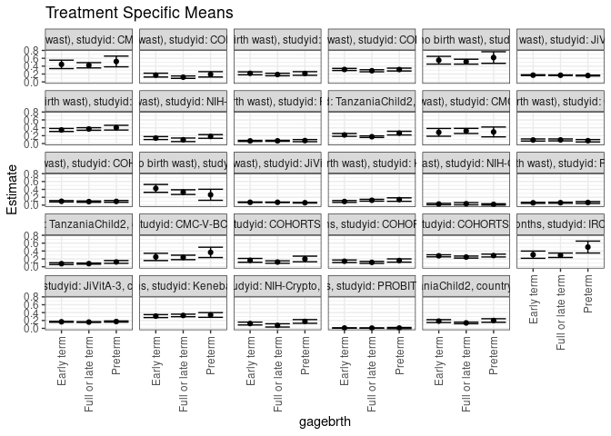

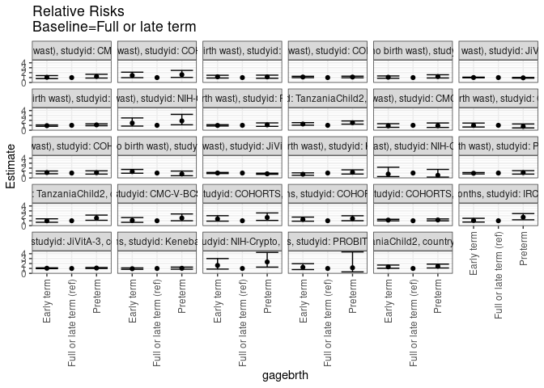

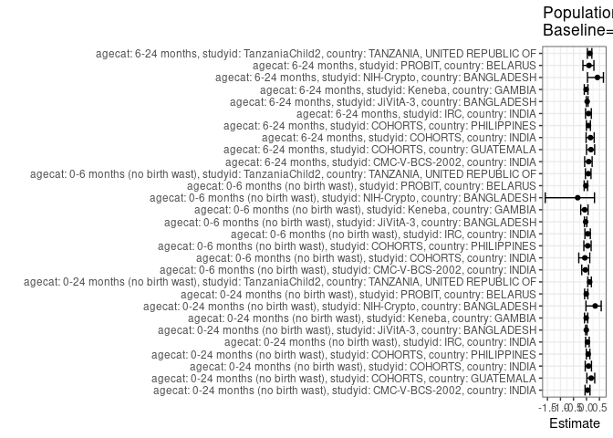

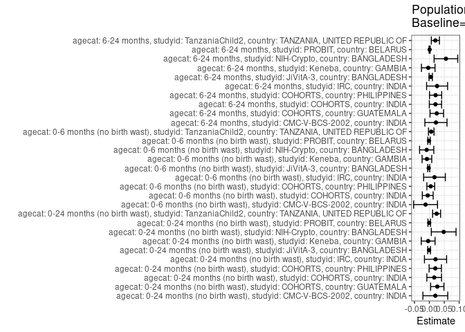

## Results Table

### Parameter: TSM

| agecat | studyid | country | intervention_level | baseline_level | estimate | ci_lower | ci_upper |
| --- | --- | --- | --- | --- | --- | --- | --- |
| 0-24 months (no birth wast) | CMC-V-BCS-2002 | INDIA | Full or late term | NA | 0.4225352 | 0.3561032 | 0.4889672 |
| 0-24 months (no birth wast) | CMC-V-BCS-2002 | INDIA | Preterm | NA | 0.5192308 | 0.3832367 | 0.6552248 |
| 0-24 months (no birth wast) | CMC-V-BCS-2002 | INDIA | Early term | NA | 0.4457831 | 0.3386964 | 0.5528699 |
| 0-24 months (no birth wast) | COHORTS | GUATEMALA | Full or late term | NA | 0.1205357 | 0.0903678 | 0.1507036 |
| 0-24 months (no birth wast) | COHORTS | GUATEMALA | Preterm | NA | 0.1923077 | 0.1245176 | 0.2600978 |
| 0-24 months (no birth wast) | COHORTS | GUATEMALA | Early term | NA | 0.1731602 | 0.1243348 | 0.2219855 |
| 0-24 months (no birth wast) | COHORTS | INDIA | Full or late term | NA | 0.1882556 | 0.1564023 | 0.2201089 |
| 0-24 months (no birth wast) | COHORTS | INDIA | Preterm | NA | 0.2142857 | 0.1684438 | 0.2601277 |
| 0-24 months (no birth wast) | COHORTS | INDIA | Early term | NA | 0.2183406 | 0.1804917 | 0.2561895 |
| 0-24 months (no birth wast) | COHORTS | PHILIPPINES | Full or late term | NA | 0.2832470 | 0.2572912 | 0.3092027 |
| 0-24 months (no birth wast) | COHORTS | PHILIPPINES | Preterm | NA | 0.3143760 | 0.2782028 | 0.3505492 |
| 0-24 months (no birth wast) | COHORTS | PHILIPPINES | Early term | NA | 0.3161398 | 0.2898497 | 0.3424298 |
| 0-24 months (no birth wast) | IRC | INDIA | Full or late term | NA | 0.5140562 | 0.4518970 | 0.5762155 |
| 0-24 months (no birth wast) | IRC | INDIA | Preterm | NA | 0.6190476 | 0.4719926 | 0.7661026 |
| 0-24 months (no birth wast) | IRC | INDIA | Early term | NA | 0.5510204 | 0.4524172 | 0.6496236 |
| 0-24 months (no birth wast) | JiVitA-3 | BANGLADESH | Full or late term | NA | 0.1695599 | 0.1624687 | 0.1766511 |
| 0-24 months (no birth wast) | JiVitA-3 | BANGLADESH | Preterm | NA | 0.1617762 | 0.1508225 | 0.1727299 |
| 0-24 months (no birth wast) | JiVitA-3 | BANGLADESH | Early term | NA | 0.1717949 | 0.1620344 | 0.1815553 |
| 0-24 months (no birth wast) | Keneba | GAMBIA | Full or late term | NA | 0.3699284 | 0.3372314 | 0.4026254 |
| 0-24 months (no birth wast) | Keneba | GAMBIA | Preterm | NA | 0.4023438 | 0.3422567 | 0.4624308 |
| 0-24 months (no birth wast) | Keneba | GAMBIA | Early term | NA | 0.3444816 | 0.3063837 | 0.3825795 |
| 0-24 months (no birth wast) | NIH-Crypto | BANGLADESH | Full or late term | NA | 0.0952381 | 0.0508206 | 0.1396556 |
| 0-24 months (no birth wast) | NIH-Crypto | BANGLADESH | Preterm | NA | 0.1800766 | 0.1334288 | 0.2267244 |
| 0-24 months (no birth wast) | NIH-Crypto | BANGLADESH | Early term | NA | 0.1384615 | 0.1008868 | 0.1760363 |
| 0-24 months (no birth wast) | PROBIT | BELARUS | Full or late term | NA | 0.0685535 | 0.0562027 | 0.0809043 |
| 0-24 months (no birth wast) | PROBIT | BELARUS | Preterm | NA | 0.0744501 | 0.0472655 | 0.1016347 |
| 0-24 months (no birth wast) | PROBIT | BELARUS | Early term | NA | 0.0669101 | 0.0540762 | 0.0797440 |
| 0-24 months (no birth wast) | TanzaniaChild2 | TANZANIA, UNITED REPUBLIC OF | Full or late term | NA | 0.1732852 | 0.1533473 | 0.1932231 |
| 0-24 months (no birth wast) | TanzaniaChild2 | TANZANIA, UNITED REPUBLIC OF | Preterm | NA | 0.2645349 | 0.2179132 | 0.3111566 |
| 0-24 months (no birth wast) | TanzaniaChild2 | TANZANIA, UNITED REPUBLIC OF | Early term | NA | 0.2183236 | 0.1825675 | 0.2540797 |

[output cut: 57 more lines]

### Parameter: E(Y)

| agecat | studyid | country | intervention_level | baseline_level | estimate | ci_lower | ci_upper |
| --- | --- | --- | --- | --- | --- | --- | --- |
| 0-24 months (no birth wast) | CMC-V-BCS-2002 | INDIA | NA | NA | 0.4425287 | 0.3902692 | 0.4947882 |
| 0-24 months (no birth wast) | COHORTS | GUATEMALA | NA | NA | 0.1470952 | 0.1226726 | 0.1715178 |
| 0-24 months (no birth wast) | COHORTS | INDIA | NA | NA | 0.2044610 | 0.1828992 | 0.2260227 |
| 0-24 months (no birth wast) | COHORTS | PHILIPPINES | NA | NA | 0.3030404 | 0.2865732 | 0.3195077 |
| 0-24 months (no birth wast) | IRC | INDIA | NA | NA | 0.5347044 | 0.4850733 | 0.5843354 |
| 0-24 months (no birth wast) | JiVitA-3 | BANGLADESH | NA | NA | 0.1686060 | 0.1631976 | 0.1740145 |
| 0-24 months (no birth wast) | Keneba | GAMBIA | NA | NA | 0.3658392 | 0.3428819 | 0.3887966 |
| 0-24 months (no birth wast) | NIH-Crypto | BANGLADESH | NA | NA | 0.1432361 | 0.1182149 | 0.1682572 |
| 0-24 months (no birth wast) | PROBIT | BELARUS | NA | NA | 0.0680135 | 0.0562135 | 0.0798135 |
| 0-24 months (no birth wast) | TanzaniaChild2 | TANZANIA, UNITED REPUBLIC OF | NA | NA | 0.1975914 | 0.1811057 | 0.2140772 |
| 0-6 months (no birth wast) | CMC-V-BCS-2002 | INDIA | NA | NA | 0.3072289 | 0.2575285 | 0.3569293 |
| 0-6 months (no birth wast) | COHORTS | INDIA | NA | NA | 0.0864692 | 0.0708761 | 0.1020623 |
| 0-6 months (no birth wast) | COHORTS | PHILIPPINES | NA | NA | 0.0942127 | 0.0837084 | 0.1047169 |
| 0-6 months (no birth wast) | IRC | INDIA | NA | NA | 0.3477089 | 0.2991827 | 0.3962350 |
| 0-6 months (no birth wast) | JiVitA-3 | BANGLADESH | NA | NA | 0.0703622 | 0.0666948 | 0.0740296 |
| 0-6 months (no birth wast) | Keneba | GAMBIA | NA | NA | 0.1156550 | 0.0998052 | 0.1315047 |
| 0-6 months (no birth wast) | NIH-Crypto | BANGLADESH | NA | NA | 0.0267023 | 0.0151493 | 0.0382553 |
| 0-6 months (no birth wast) | PROBIT | BELARUS | NA | NA | 0.0612233 | 0.0502388 | 0.0722078 |
| 0-6 months (no birth wast) | TanzaniaChild2 | TANZANIA, UNITED REPUBLIC OF | NA | NA | 0.0859445 | 0.0743193 | 0.0975697 |
| 6-24 months | CMC-V-BCS-2002 | INDIA | NA | NA | 0.2592593 | 0.2133485 | 0.3051700 |
| 6-24 months | COHORTS | GUATEMALA | NA | NA | 0.1443433 | 0.1194882 | 0.1691984 |
| 6-24 months | COHORTS | INDIA | NA | NA | 0.1318764 | 0.1136647 | 0.1500881 |
| 6-24 months | COHORTS | PHILIPPINES | NA | NA | 0.2669537 | 0.2505274 | 0.2833801 |
| 6-24 months | IRC | INDIA | NA | NA | 0.3179487 | 0.2716722 | 0.3642252 |
| 6-24 months | JiVitA-3 | BANGLADESH | NA | NA | 0.1648358 | 0.1585302 | 0.1711415 |
| 6-24 months | Keneba | GAMBIA | NA | NA | 0.3241590 | 0.3014644 | 0.3468537 |
| 6-24 months | NIH-Crypto | BANGLADESH | NA | NA | 0.1315068 | 0.1069744 | 0.1560393 |
| 6-24 months | PROBIT | BELARUS | NA | NA | 0.0083745 | 0.0044130 | 0.0123360 |
| 6-24 months | TanzaniaChild2 | TANZANIA, UNITED REPUBLIC OF | NA | NA | 0.1591987 | 0.1427306 | 0.1756669 |

### Parameter: RR

| agecat | studyid | country | intervention_level | baseline_level | estimate | ci_lower | ci_upper |
| --- | --- | --- | --- | --- | --- | --- | --- |
| 0-24 months (no birth wast) | CMC-V-BCS-2002 | INDIA | Full or late term | Full or late term | 1.0000000 | 1.0000000 | 1.0000000 |
| 0-24 months (no birth wast) | CMC-V-BCS-2002 | INDIA | Preterm | Full or late term | 1.2288462 | 0.9053765 | 1.6678839 |
| 0-24 months (no birth wast) | CMC-V-BCS-2002 | INDIA | Early term | Full or late term | 1.0550201 | 0.7917273 | 1.4058721 |
| 0-24 months (no birth wast) | COHORTS | GUATEMALA | Full or late term | Full or late term | 1.0000000 | 1.0000000 | 1.0000000 |
| 0-24 months (no birth wast) | COHORTS | GUATEMALA | Preterm | Full or late term | 1.5954416 | 1.0354412 | 2.4583085 |
| 0-24 months (no birth wast) | COHORTS | GUATEMALA | Early term | Full or late term | 1.4365881 | 0.9853568 | 2.0944550 |
| 0-24 months (no birth wast) | COHORTS | INDIA | Full or late term | Full or late term | 1.0000000 | 1.0000000 | 1.0000000 |
| 0-24 months (no birth wast) | COHORTS | INDIA | Preterm | Full or late term | 1.1382700 | 0.8665417 | 1.4952062 |
| 0-24 months (no birth wast) | COHORTS | INDIA | Early term | Full or late term | 1.1598093 | 0.9102995 | 1.4777088 |
| 0-24 months (no birth wast) | COHORTS | PHILIPPINES | Full or late term | Full or late term | 1.0000000 | 1.0000000 | 1.0000000 |
| 0-24 months (no birth wast) | COHORTS | PHILIPPINES | Preterm | Full or late term | 1.1099006 | 0.9580798 | 1.2857794 |
| 0-24 months (no birth wast) | COHORTS | PHILIPPINES | Early term | Full or late term | 1.1161276 | 0.9862163 | 1.2631517 |
| 0-24 months (no birth wast) | IRC | INDIA | Full or late term | Full or late term | 1.0000000 | 1.0000000 | 1.0000000 |
| 0-24 months (no birth wast) | IRC | INDIA | Preterm | Full or late term | 1.2042411 | 0.9224653 | 1.5720879 |
| 0-24 months (no birth wast) | IRC | INDIA | Early term | Full or late term | 1.0719069 | 0.8636986 | 1.3303072 |
| 0-24 months (no birth wast) | JiVitA-3 | BANGLADESH | Full or late term | Full or late term | 1.0000000 | 1.0000000 | 1.0000000 |
| 0-24 months (no birth wast) | JiVitA-3 | BANGLADESH | Preterm | Full or late term | 0.9540946 | 0.8838495 | 1.0299226 |
| 0-24 months (no birth wast) | JiVitA-3 | BANGLADESH | Early term | Full or late term | 1.0131809 | 0.9461475 | 1.0849636 |
| 0-24 months (no birth wast) | Keneba | GAMBIA | Full or late term | Full or late term | 1.0000000 | 1.0000000 | 1.0000000 |
| 0-24 months (no birth wast) | Keneba | GAMBIA | Preterm | Full or late term | 1.0876260 | 0.9143508 | 1.2937379 |
| 0-24 months (no birth wast) | Keneba | GAMBIA | Early term | Full or late term | 0.9312116 | 0.8082821 | 1.0728370 |
| 0-24 months (no birth wast) | NIH-Crypto | BANGLADESH | Full or late term | Full or late term | 1.0000000 | 1.0000000 | 1.0000000 |
| 0-24 months (no birth wast) | NIH-Crypto | BANGLADESH | Preterm | Full or late term | 1.8908046 | 1.1090532 | 3.2235984 |
| 0-24 months (no birth wast) | NIH-Crypto | BANGLADESH | Early term | Full or late term | 1.4538462 | 0.8475737 | 2.4937873 |
| 0-24 months (no birth wast) | PROBIT | BELARUS | Full or late term | Full or late term | 1.0000000 | 1.0000000 | 1.0000000 |
| 0-24 months (no birth wast) | PROBIT | BELARUS | Preterm | Full or late term | 1.0860138 | 0.7903905 | 1.4922068 |
| 0-24 months (no birth wast) | PROBIT | BELARUS | Early term | Full or late term | 0.9760275 | 0.8531686 | 1.1165785 |
| 0-24 months (no birth wast) | TanzaniaChild2 | TANZANIA, UNITED REPUBLIC OF | Full or late term | Full or late term | 1.0000000 | 1.0000000 | 1.0000000 |
| 0-24 months (no birth wast) | TanzaniaChild2 | TANZANIA, UNITED REPUBLIC OF | Preterm | Full or late term | 1.5265867 | 1.2368416 | 1.8842082 |
| 0-24 months (no birth wast) | TanzaniaChild2 | TANZANIA, UNITED REPUBLIC OF | Early term | Full or late term | 1.2599090 | 1.0313694 | 1.5390904 |

[output cut: 57 more lines]

### Parameter: PAR

| agecat | studyid | country | intervention_level | baseline_level | estimate | ci_lower | ci_upper |
| --- | --- | --- | --- | --- | --- | --- | --- |
| 0-24 months (no birth wast) | CMC-V-BCS-2002 | INDIA | Full or late term | NA | 0.0199935 | -0.0217424 | 0.0617295 |
| 0-24 months (no birth wast) | COHORTS | GUATEMALA | Full or late term | NA | 0.0265595 | 0.0042303 | 0.0488886 |
| 0-24 months (no birth wast) | COHORTS | INDIA | Full or late term | NA | 0.0162054 | -0.0084113 | 0.0408220 |
| 0-24 months (no birth wast) | COHORTS | PHILIPPINES | Full or late term | NA | 0.0197935 | -0.0007871 | 0.0403740 |
| 0-24 months (no birth wast) | IRC | INDIA | Full or late term | NA | 0.0206481 | -0.0165082 | 0.0578045 |
| 0-24 months (no birth wast) | JiVitA-3 | BANGLADESH | Full or late term | NA | -0.0009539 | -0.0056729 | 0.0037651 |
| 0-24 months (no birth wast) | Keneba | GAMBIA | Full or late term | NA | -0.0040892 | -0.0272656 | 0.0190873 |
| 0-24 months (no birth wast) | NIH-Crypto | BANGLADESH | Full or late term | NA | 0.0479980 | 0.0065276 | 0.0894684 |
| 0-24 months (no birth wast) | PROBIT | BELARUS | Full or late term | NA | -0.0005400 | -0.0047769 | 0.0036968 |
| 0-24 months (no birth wast) | TanzaniaChild2 | TANZANIA, UNITED REPUBLIC OF | Full or late term | NA | 0.0243062 | 0.0109585 | 0.0376540 |
| 0-6 months (no birth wast) | CMC-V-BCS-2002 | INDIA | Full or late term | NA | -0.0127711 | -0.0529146 | 0.0273724 |
| 0-6 months (no birth wast) | COHORTS | INDIA | Full or late term | NA | -0.0054633 | -0.0236669 | 0.0127403 |
| 0-6 months (no birth wast) | COHORTS | PHILIPPINES | Full or late term | NA | 0.0046474 | -0.0084655 | 0.0177604 |
| 0-6 months (no birth wast) | IRC | INDIA | Full or late term | NA | 0.0171650 | -0.0192524 | 0.0535823 |
| 0-6 months (no birth wast) | JiVitA-3 | BANGLADESH | Full or late term | NA | -0.0022420 | -0.0055638 | 0.0010798 |
| 0-6 months (no birth wast) | Keneba | GAMBIA | Full or late term | NA | -0.0082042 | -0.0243903 | 0.0079818 |
| 0-6 months (no birth wast) | NIH-Crypto | BANGLADESH | Full or late term | NA | -0.0090120 | -0.0328503 | 0.0148263 |
| 0-6 months (no birth wast) | PROBIT | BELARUS | Full or late term | NA | -0.0012694 | -0.0053324 | 0.0027936 |
| 0-6 months (no birth wast) | TanzaniaChild2 | TANZANIA, UNITED REPUBLIC OF | Full or late term | NA | 0.0062343 | -0.0030954 | 0.0155641 |
| 6-24 months | CMC-V-BCS-2002 | INDIA | Full or late term | NA | 0.0220500 | -0.0150725 | 0.0591725 |
| 6-24 months | COHORTS | GUATEMALA | Full or late term | NA | 0.0249054 | 0.0022546 | 0.0475561 |
| 6-24 months | COHORTS | INDIA | Full or late term | NA | 0.0203782 | -0.0001442 | 0.0409005 |
| 6-24 months | COHORTS | PHILIPPINES | Full or late term | NA | 0.0208853 | 0.0004470 | 0.0413235 |
| 6-24 months | IRC | INDIA | Full or late term | NA | 0.0259487 | -0.0093107 | 0.0612081 |
| 6-24 months | JiVitA-3 | BANGLADESH | Full or late term | NA | 0.0045070 | -0.0011531 | 0.0101670 |
| 6-24 months | Keneba | GAMBIA | Full or late term | NA | -0.0038508 | -0.0266434 | 0.0189418 |
| 6-24 months | NIH-Crypto | BANGLADESH | Full or late term | NA | 0.0555575 | 0.0159234 | 0.0951916 |
| 6-24 months | PROBIT | BELARUS | Full or late term | NA | 0.0008264 | -0.0009328 | 0.0025857 |
| 6-24 months | TanzaniaChild2 | TANZANIA, UNITED REPUBLIC OF | Full or late term | NA | 0.0201659 | 0.0066217 | 0.0337102 |

### Parameter: PAF

| agecat | studyid | country | intervention_level | baseline_level | estimate | ci_lower | ci_upper |
| --- | --- | --- | --- | --- | --- | --- | --- |
| 0-24 months (no birth wast) | CMC-V-BCS-2002 | INDIA | Full or late term | NA | 0.0451802 | -0.0540332 | 0.1350548 |
| 0-24 months (no birth wast) | COHORTS | GUATEMALA | Full or late term | NA | 0.1805597 | 0.0163590 | 0.3173502 |
| 0-24 months (no birth wast) | COHORTS | INDIA | Full or late term | NA | 0.0792589 | -0.0491907 | 0.1919828 |
| 0-24 months (no birth wast) | COHORTS | PHILIPPINES | Full or late term | NA | 0.0653162 | -0.0051067 | 0.1308050 |
| 0-24 months (no birth wast) | IRC | INDIA | Full or late term | NA | 0.0386160 | -0.0335666 | 0.1057575 |
| 0-24 months (no birth wast) | JiVitA-3 | BANGLADESH | Full or late term | NA | -0.0056575 | -0.0340443 | 0.0219500 |
| 0-24 months (no birth wast) | Keneba | GAMBIA | Full or late term | NA | -0.0111775 | -0.0765563 | 0.0502309 |
| 0-24 months (no birth wast) | NIH-Crypto | BANGLADESH | Full or late term | NA | 0.3350970 | -0.0205567 | 0.5668090 |
| 0-24 months (no birth wast) | PROBIT | BELARUS | Full or late term | NA | -0.0079400 | -0.0722836 | 0.0525427 |
| 0-24 months (no birth wast) | TanzaniaChild2 | TANZANIA, UNITED REPUBLIC OF | Full or late term | NA | 0.1230126 | 0.0532702 | 0.1876173 |
| 0-6 months (no birth wast) | CMC-V-BCS-2002 | INDIA | Full or late term | NA | -0.0415686 | -0.1807664 | 0.0812194 |
| 0-6 months (no birth wast) | COHORTS | INDIA | Full or late term | NA | -0.0631818 | -0.2956919 | 0.1276046 |
| 0-6 months (no birth wast) | COHORTS | PHILIPPINES | Full or late term | NA | 0.0493292 | -0.1004591 | 0.1787292 |
| 0-6 months (no birth wast) | IRC | INDIA | Full or late term | NA | 0.0493659 | -0.0613601 | 0.1485404 |
| 0-6 months (no birth wast) | JiVitA-3 | BANGLADESH | Full or late term | NA | -0.0318637 | -0.0800928 | 0.0142119 |
| 0-6 months (no birth wast) | Keneba | GAMBIA | Full or late term | NA | -0.0709372 | -0.2201672 | 0.0600415 |
| 0-6 months (no birth wast) | NIH-Crypto | BANGLADESH | Full or late term | NA | -0.3375000 | -1.5855791 | 0.3081216 |
| 0-6 months (no birth wast) | PROBIT | BELARUS | Full or late term | NA | -0.0207340 | -0.0892978 | 0.0435141 |
| 0-6 months (no birth wast) | TanzaniaChild2 | TANZANIA, UNITED REPUBLIC OF | Full or late term | NA | 0.0725393 | -0.0422120 | 0.1746559 |
| 6-24 months | CMC-V-BCS-2002 | INDIA | Full or late term | NA | 0.0850498 | -0.0696159 | 0.2173510 |
| 6-24 months | COHORTS | GUATEMALA | Full or late term | NA | 0.1725426 | 0.0022169 | 0.3137930 |
| 6-24 months | COHORTS | INDIA | Full or late term | NA | 0.1545246 | -0.0150246 | 0.2957524 |
| 6-24 months | COHORTS | PHILIPPINES | Full or late term | NA | 0.0782355 | -0.0015408 | 0.1516574 |
| 6-24 months | IRC | INDIA | Full or late term | NA | 0.0816129 | -0.0361537 | 0.1859944 |
| 6-24 months | JiVitA-3 | BANGLADESH | Full or late term | NA | 0.0273421 | -0.0076506 | 0.0611196 |
| 6-24 months | Keneba | GAMBIA | Full or late term | NA | -0.0118794 | -0.0846928 | 0.0560462 |
| 6-24 months | NIH-Crypto | BANGLADESH | Full or late term | NA | 0.4224684 | 0.0412055 | 0.6521227 |
| 6-24 months | PROBIT | BELARUS | Full or late term | NA | 0.0986856 | -0.1372698 | 0.2856861 |
| 6-24 months | TanzaniaChild2 | TANZANIA, UNITED REPUBLIC OF | Full or late term | NA | 0.1266714 | 0.0380590 | 0.2071209 |